# Comprehensive Overview of R

Boyoon Chang

19 October 2021

## 1. Review of R

### Install and load the packages

- If it’s your first time using the package, you are most likely to have not installed it. Then run `install.packages("<packageName>")`. ( Replace with the actual name of the package, i.e. `install.packages("tidyverse")` )
- Installation and loading it is two separate thing, just like you need to click on the software to initialize it after installing it on your laptop, you need to run `library()` to load the package on your R studio. (i.e., `library('tidyverse')`)

### What are packages?

‘R packages are collection of **functions** and **data sets** developed by the community’ [Retrieved from here](https://www.datacamp.com/community/tutorials/r-packages-guide)

### What is a function?

- Examples: print(), ggplot(), select(), filter(), etc.
- Let’s create one!

```r
addition = function(param1, param2){
  result = param1+param2
  return(result)
}
# param1, param2 are referred to as input parameters of the addition function.
```

Side note: parameters of regression equation is $\beta_1$, $\beta_2$ in $Y _i=\beta_1 + \beta_2 X_i + u_i$ (more on this on page 85 of the textbook)

```r
addition(param1=1,param2=2)
```

```
## [1] 3
```

```r
# 1 and 2 are referred to as the arguments of the function call.
subtraction = function(banana, apple){
  result = banana-apple
  return(result)
}
# By default, unless specified otherwise, banana=2, apple=3 because banana comes before apple in the order of parameters in the function.
subtraction(banana=2, apple=3)
```

```
## [1] -1
```

```r
subtraction(2,3)
```

```
## [1] -1
```

```r
# If we specify parameters with corresponding arguments, order doesn't matter.
subtraction(apple=2,banana=3)
```

```
## [1] 1
```

```r
print
```

```
## function (x, ...)
## UseMethod("print")
## <bytecode: 0x7ffbb99155b0>
## <environment: namespace:base>
```

```r
library(gapminder)
library(ggplot2)
geom_vline
```

```
## function (mapping = NULL, data = NULL, ..., xintercept, na.rm = FALSE,
##     show.legend = NA)
## {
##     if (!missing(xintercept)) {
##         if (!is.null(mapping)) {
##             warn_overwritten_args("geom_vline()", "mapping",
##                 "xintercept")
##         }
##         if (!is.null(data)) {
##             warn_overwritten_args("geom_vline()", "data", "xintercept")
##         }
##         data <- new_data_frame(list(xintercept = xintercept))
##         mapping <- aes(xintercept = xintercept)
##         show.legend <- FALSE
##     }
##     layer(data = data, mapping = mapping, stat = StatIdentity,
##         geom = GeomVline, position = PositionIdentity, show.legend = show.legend,
##         inherit.aes = FALSE, params = list(na.rm = na.rm, ...))
## }
## <bytecode: 0x7ffbafa7ded0>
## <environment: namespace:ggplot2>
```

```r
aes
```

```
## function (x, y, ...)
## {
##     exprs <- enquos(x = x, y = y, ..., .ignore_empty = "all")
##     aes <- new_aes(exprs, env = parent.frame())
##     rename_aes(aes)
## }
## <bytecode: 0x7ffbafad54e8>
## <environment: namespace:ggplot2>
```

```r
ggplot(gapminder, aes(x=gdpPercap, y=lifeExp)) + geom_point()
```

[output not shown]

```r
# Following code won't run.
# ggplot(aes(x=gdpPercap, y=lifeExp), gapminder) + geom_point()
ggplot(mapping=aes(x=gdpPercap, y=lifeExp), data = gapminder) + geom_point()
```

[output not shown]

## 2. Review of ggplot

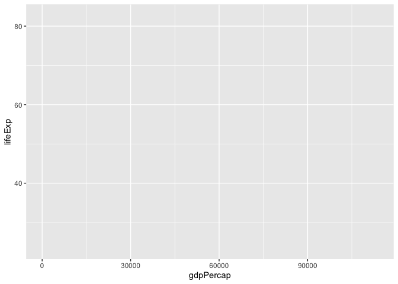

```r
library(ggplot2)
ggplot(data = gapminder, mapping=aes(x=gdpPercap, y=lifeExp))
```

```r
ggplot(data = gapminder, mapping=aes(x=gdpPercap, y=lifeExp)) +
  geom_point()
```

[output not shown]

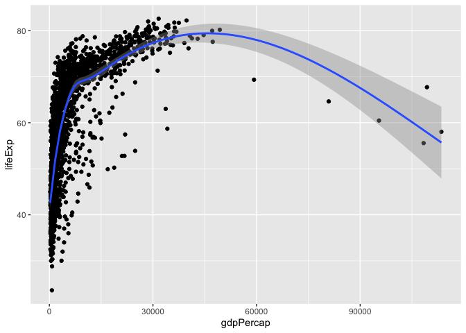

```r
ggplot(data = gapminder, mapping=aes(x=gdpPercap, y=lifeExp)) +
  geom_point()+
  geom_smooth()
```

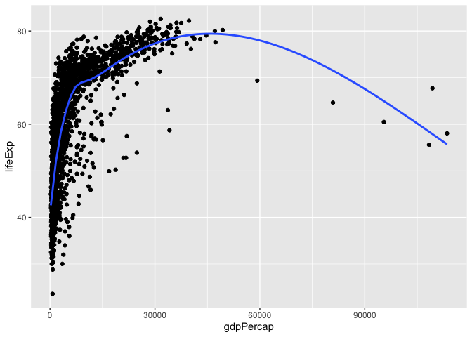

```r
ggplot(data = gapminder, mapping=aes(x=gdpPercap, y=lifeExp)) +
  geom_point()+
  geom_smooth(se=FALSE)
```

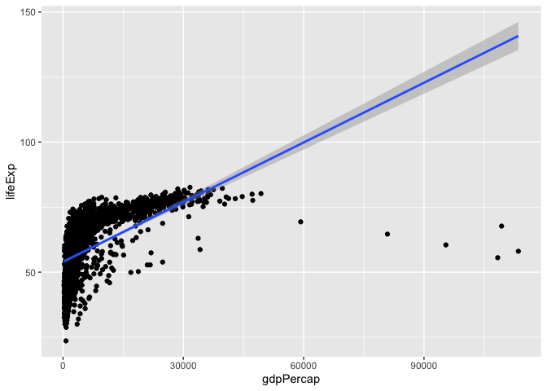

```r
ggplot(data = gapminder, mapping=aes(x=gdpPercap, y=lifeExp)) +
  geom_point()+
  geom_smooth(method="lm")
```

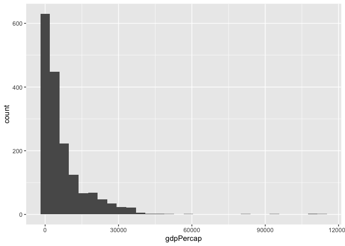

```r
ggplot(data = gapminder, mapping=aes(x=gdpPercap)) +
  geom_histogram()
```

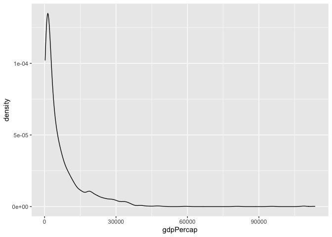

```r
ggplot(data = gapminder, mapping=aes(x=gdpPercap)) +
  geom_density()
```

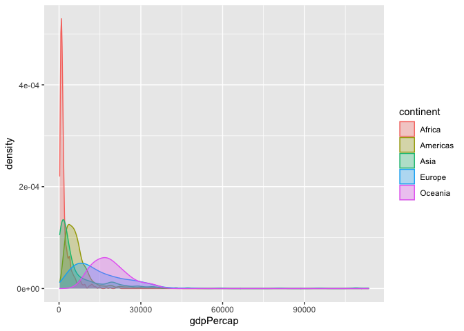

```r
ggplot(data = gapminder, mapping=aes(x=gdpPercap, color=continent, fill=continent)) +
  geom_density(alpha=0.3)
```

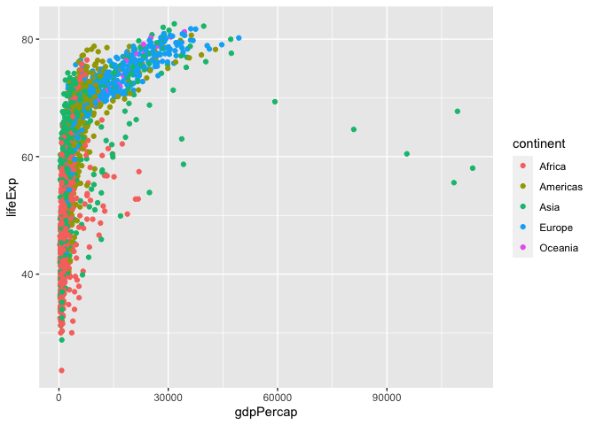

```r
ggplot(data = gapminder, mapping=aes(y=lifeExp,
                                     x=gdpPercap,
                                     color=continent)) +
  geom_point()
```

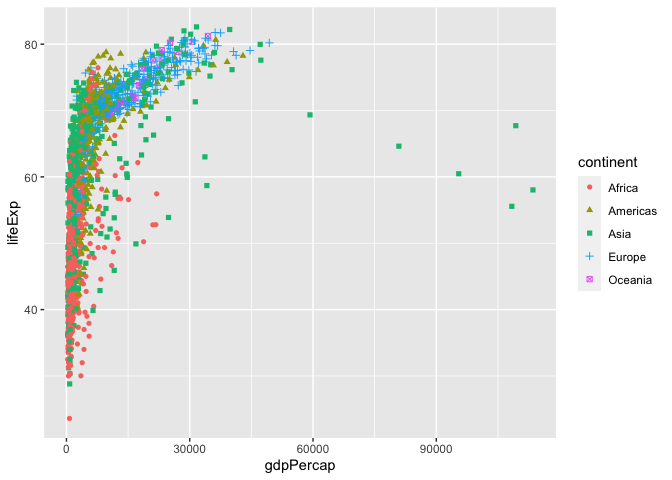

```r
ggplot(data = gapminder, mapping=aes(y=lifeExp,
                                     x=gdpPercap,
                                     color=continent,
                                     shape=continent)) +
  geom_point()
```

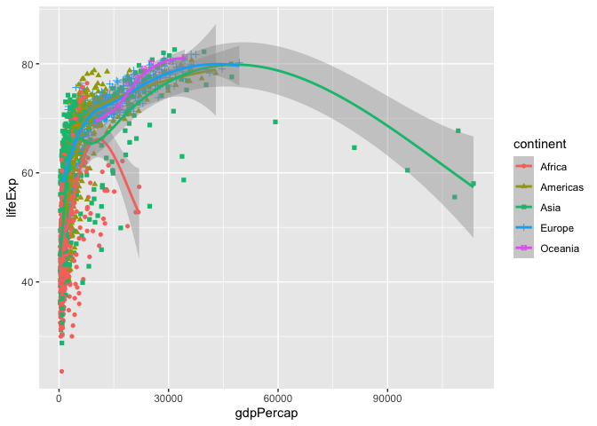

```r
ggplot(data = gapminder, mapping=aes(y=lifeExp,
                                     x=gdpPercap,
                                     color=continent,
                                     shape=continent)) +
  geom_point()+
  geom_smooth()
```

## 3. Import external data

### Load tidyverse

```r
library(tidyverse)
```

### read_csv() function in tidyverse package

- R will look for the file called ‘lab3.csv’
- But where is the lab3.csv?
- We need to specify the location of this file, such that R knows where to look for the file.

```r
# Below code won't run because R doesn't know which folder to look at for lab3.csv.
# cps <- read_csv("lab3.csv")
# You could code out like below, where you specify where the file is in
cps <- read_csv('/Users/boyoonc/ec320_labs/lab3/lab3.csv')
```

**OR** **In order to make `cps <- read_csv("lab3.csv")` code run by itself, we need to follow below steps:**

Step 1: This code allows us to see which directory that R is operating in.

```r
getwd()
```

```
## [1] "/Users/boyoonc/ec320_labs/lab3"
```

Step 2: We set the working directory to be the one inside the quotes, which would indicate the location of the file ‘lab3.csv’.

```r
setwd('/Users/boyoonc/ec320_labs/lab3')
```

Step 3: Now R will look for file that is inside the working directory even if we don’t specify the location of the file like the code above because by default R looks for ‘lab3.csv’ file first from the **working directory**. Now `cps=read_csv('lab3.csv')` runs by itself.

```r
cps = read_csv('lab3.csv')
```

## 4. Data analysis

### Get a grasp about the data structure

- View(): open another tab that shows the data
- glimpse(): returns number of rows and columns as well as some observations
- dim(): returns the dimension of the data
- summary(): summary about each variable
- names(): names of the variables

### Pipe operator

```r
?summarize()
?group_by()
cps %>%
  group_by(black, female) %>%
  summarize(employed = mean(employed, na.rm = TRUE))
```

```
## # A tibble: 4 × 3
## # Groups:   black [2]
##   black female employed
##   <dbl>  <dbl>    <dbl>
## 1     0      0    0.868
## 2     0      1    0.723
## 3     1      0    0.718
## 4     1      1    0.693
```

```r
# Equivalently,
summarize(group_by(cps, black, female),
          employed = mean(employed, na.rm = TRUE))
```

```
## # A tibble: 4 × 3
## # Groups:   black [2]
##   black female employed
##   <dbl>  <dbl>    <dbl>
## 1     0      0    0.868
## 2     0      1    0.723
## 3     1      0    0.718
## 4     1      1    0.693
```

### Dummy variable

```r
table(cps$employed)
```

```
##
##    0    1
## 1942 6931
```

```r
c(sample(c(0,1), 10, prob=c(0.5,0.5), replace=TRUE)) %>%
  print() %>%
  mean()
```

```
##  [1] 0 1 0 0 0 0 0 1 0 0
```

```
## [1] 0.2
```

```r
# The fraction of 1s in the entire observations, or in the sample
# The percentage of individuals in the sample who denoted as 1s.
mean(cps$employed, na.rm = TRUE)
```

```
## [1] 0.7811338
```

```r
cps %>% group_by(black) %>% summarize(mean(employed, na.rm=TRUE)) %>%
  c(diff=.[[2,2]]-.[[1,2]])
```

```
## $black
## [1] 0 1
##
## $`mean(employed, na.rm = TRUE)`
## [1] 0.7948786 0.7035928
##
## $diff
## [1] -0.09128578
```

### t-stat

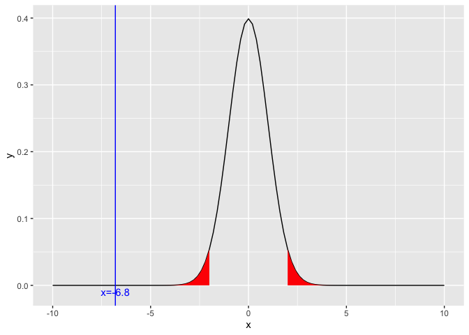

```r
ggplot()+
  stat_function(fun=dt, args=list(df=8871), geom="line")+
  stat_function(fun=dt, args=list(df=8871), geom="area", fill="red", xlim=c(-5,-2)) +
  stat_function(fun=dt, args=list(df=8871), geom="area", fill="red", xlim=c(2,5)) +
  xlim(-10,10)+
  geom_vline(xintercept=-6.8, color="blue")+
  annotate("text", x= -6.8, y=-0.01,label="x=-6.8", color="blue")
```